# Лабораторна робота №2

## Тема: Налагоджування та робота в середовищі Anaconda + Quarto

### **Студент:** Варакута Олександр

### **Група:** КІ-24-1

## 1. Завантаження та встановлення Anaconda

### 1.1 Завантаження

Перейдіть на сайт [Anaconda](https://www.anaconda.com/products/distribution) та завантажте дистрибутив для вашої операційної системи.

### 1.2 Встановлення

1. Запустіть інсталятор.
2. Оберіть "Install for: Just Me (Recommended)".
3. Вкажіть шлях (`C:\Users\ВашКористувач\Anaconda3`).
4. Додайте Anaconda до змінних середовища (PATH).
5. Дочекайтеся завершення установки.

*Перевіримо встановлення:*

```python
!conda --version
!python --version
```

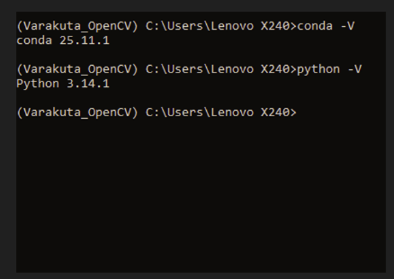

## 2. Створення та перевірка віртуального середовища

```python
!conda env list
```

```
# conda environments:
#
# * -> active
# + -> frozen
base                 *   C:\Anaconda3
Varakuta_OpenCV          C:\Anaconda3\envs\Varakuta_OpenCV
```

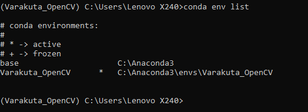

## 3. Встановлення необхідних бібліотек

```python
!conda list
```

[output not shown]

[output cut: 502 more lines]

[output not shown]

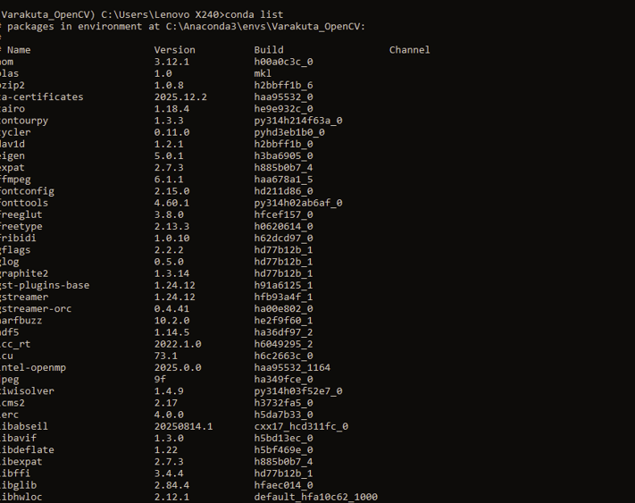

## Контрольні запитання та відповіді

#### 1. Що таке pip і conda та чим вони відрізняються між собою?

**pip** – це стандартний менеджер пакетів Python, який використовується для встановлення та управління бібліотеками з PyPI (Python Package Index).

**conda** – це менеджер пакетів та віртуальних середовищ, який входить до складу Anaconda. Він дозволяє встановлювати пакети як для Python, так і для інших мов програмування (наприклад, R).

Основні відмінності:

- pip працює лише з пакетами Python, conda підтримує інші типи пакетів.
- conda керує залежностями більш ефективно, оскільки може встановлювати бібліотеки у форматах, що не потребують компіляції.
- conda має вбудовані механізми для створення та управління віртуальними середовищами.

#### 2. Як виконати налаштування середовища за допомогою Virtualenv?

##### Покрокова інструкція:

1. Встановити Virtualenv: `pip install virtualenv`
2. Створити нове середовище: `virtualenv myenv`
3. Активувати середовище: `myenv\Scripts\activate`
4. Встановити необхідні пакети (наприклад, OpenCV): `pip install opencv-python`
5. Деактивувати середовище: `deactivate`

#### 3. Сфотографувати себе на телефон та імпортувати своє зображення у форматі .png на початок робочого зошита.

Кроки:

1. Перенести зображення у директорію з файлом .ipynb (наприклад, у папку images).
2. Додати зображення у Jupyter Notebook за допомогою Markdown: `![My Photo](images/my_photo.png)`

#### 4: Bubble Sort (Метод бульбашки)

```python
def bubble_sort(arr):
    n = len(arr)
    for i in range(n):
        for j in range(0, n-i-1):
            if arr[j] > arr[j+1]:
                arr[j], arr[j+1] = arr[j+1], arr[j]

# Приклад
arr = [74, 32, 27, 4, 25, 29, 10]
bubble_sort(arr)
print("Відсортований масив:", arr)
```

```
Відсортований масив: [4, 10, 25, 27, 29, 32, 74]
```

#### 5. Як виконати компіляцію вхідного документа Jupyter Notebook з його середовища, не використовуючи інтерфейс командного рядка?

У Jupyter Notebook можна експортувати .ipynb у .html, .pdf або .md без використання командного рядка:

1. Відкрити Jupyter Notebook.
2. У верхньому меню натиснути File → Download as.
3. Обрати потрібний формат:
   - HTML (.html)
   - PDF via LaTeX (.pdf)
   - Markdown (.md)

#### 6. Як виконати компіляцію Jupyter Notebook у HTML?

Для конвертації Jupyter Notebook у HTML можна використати:

1. **Через командний рядок**: `jupyter nbconvert lab_2_StudentLastName.ipynb --to html`
2. **За допомогою Quarto** `quarto preview lab_2_StudentLastName.ipynb`